# 用户消费行为分析

```python
from IPython.display import HTML
HTML('''<script>
code_show=true;
function code_toggle() {
  if (code_show){
    $(\'div.input\').hide();
  } else {
    $(\'div.input\').show();
  }
  code_show = !code_show
}
$( document ).ready(code_toggle);
</script>
  <form action="javascript:code_toggle()">
    <input type="submit" value="点击此处隐藏/显示代码.">
 </form>''')
```

```python
import pandas as pd
import numpy as np
import matplotlib as mpl
import seaborn as sns
import matplotlib.pyplot as plt
import pyecharts
from datetime import datetime
```

### 数据介绍

该数据是从网上下载的，其内容是用户购买CD的消费情况，共有四个字段，具体含义如下:

| 字段名称: | 字段含义: |
| --- | --- |
| 用户ID | 购买产品用户 ID |
| 购买日期 | 购买产品的日期 |
| 订单数 | 购买产品数量 |
| 订单金额 | 单次购买产品的金额 |

```python
columns = ['用户ID','购买日期','订单数','订单金额']
df = pd.read_table(r'D:\和鲸\CDNow网站用户消费数据集\CDNOW.txt',names = columns,sep = '\s+')
df.head()
```

|  | 用户ID | 购买日期 | 订单数 | 订单金额 |
| --- | --- | --- | --- | --- |
| 0 | 1 | 19970101 | 1 | 11.77 |
| 1 | 2 | 19970112 | 1 | 12.00 |
| 2 | 2 | 19970112 | 5 | 77.00 |
| 3 | 3 | 19970102 | 2 | 20.76 |
| 4 | 3 | 19970330 | 2 | 20.76 |

```python
df.describe()
```

|  | 用户ID | 购买日期 | 订单数 | 订单金额 |
| --- | --- | --- | --- | --- |
| count | 69659.000000 | 6.965900e+04 | 69659.000000 | 69659.000000 |
| mean | 11470.854592 | 1.997228e+07 | 2.410040 | 35.893648 |
| std | 6819.904848 | 3.837735e+03 | 2.333924 | 36.281942 |
| min | 1.000000 | 1.997010e+07 | 1.000000 | 0.000000 |
| 25% | 5506.000000 | 1.997022e+07 | 1.000000 | 14.490000 |
| 50% | 11410.000000 | 1.997042e+07 | 2.000000 | 25.980000 |
| 75% | 17273.000000 | 1.997111e+07 | 3.000000 | 43.700000 |
| max | 23570.000000 | 1.998063e+07 | 99.000000 | 1286.010000 |

```python
df.shape
```

```
(69659, 4)
```

### 先对数据进行描述统计，对用户数据特征进行整体性判断：

1、从数据的统计描述信息中可以看出，用户每个订单平均购买2.41个商品，每个订单平均消费35.89元。

2、购买商品数量的标准差为2.33，说明数据具有一定的波动性；中位数为2个商品,75分位数为3个商品，说明大部分订单的购买数量都不多。最大值在99个，数字比较高。购买金额的情况差不多，大部分订单都集中在小额。

3、一般而言，消费类的数据分布，都是长尾形态。大部分用户都是小额，然而小部分用户贡献了收入的大头，俗称二八。

### 数据处理

```python
df.info()
```

```
<class 'pandas.core.frame.DataFrame'>
RangeIndex: 69659 entries, 0 to 69658
Data columns (total 4 columns):
用户ID    69659 non-null int64
购买日期    69659 non-null int64
订单数     69659 non-null int64
订单金额    69659 non-null float64
dtypes: float64(1), int64(3)
memory usage: 2.1 MB
```

从上述中可以看出原数据没有空值，由于数据中购买日期的时间格式不对，接着将时间的数据类型转化。 当利用pandas进行数据处理的时候，经常会遇见数据类型的问题，当拿到数据的时候，首先要确定拿到的是正确的数据类型，如果数据类型不正确需要进行数据类型的转化，再进行数据处理。

```python
df['购买日期'] = pd.to_datetime(df['购买日期'],format = '%Y%m%d') #Y四位数的日期部分，y表示两位数的日期部分
df['月份'] = df['购买日期'].values.astype('datetime64[M]')
df.head()
```

|  | 用户ID | 购买日期 | 订单数 | 订单金额 | 月份 |
| --- | --- | --- | --- | --- | --- |
| 0 | 1 | 1997-01-01 | 1 | 11.77 | 1997-01-01 |
| 1 | 2 | 1997-01-12 | 1 | 12.00 | 1997-01-01 |
| 2 | 2 | 1997-01-12 | 5 | 77.00 | 1997-01-01 |
| 3 | 3 | 1997-01-02 | 2 | 20.76 | 1997-01-01 |
| 4 | 3 | 1997-03-30 | 2 | 20.76 | 1997-03-01 |

1、pd.to_datetime可以将特定的字符串或者数字转换成时间格式，其中的format参数用于匹配。例如19970101，%Y匹配前四位数字1997，如果y小写只匹配两位数字97，%m匹配01，%d匹配01。

2、另外，小时是%h，分钟是%M，注意和月的大小写不一致，秒是%s。若是1997-01-01这形式，则是%Y-%m-%d，以此类推。

3、astype也可以将时间格式进行转换，比如[M]转化成月份。我们将月份作为消费行为的主要事件窗口，选择哪种时间窗口取决于消费频率。

### 用户总体消费分析

[output not shown]

[output cut: 29 more lines]

[output not shown]

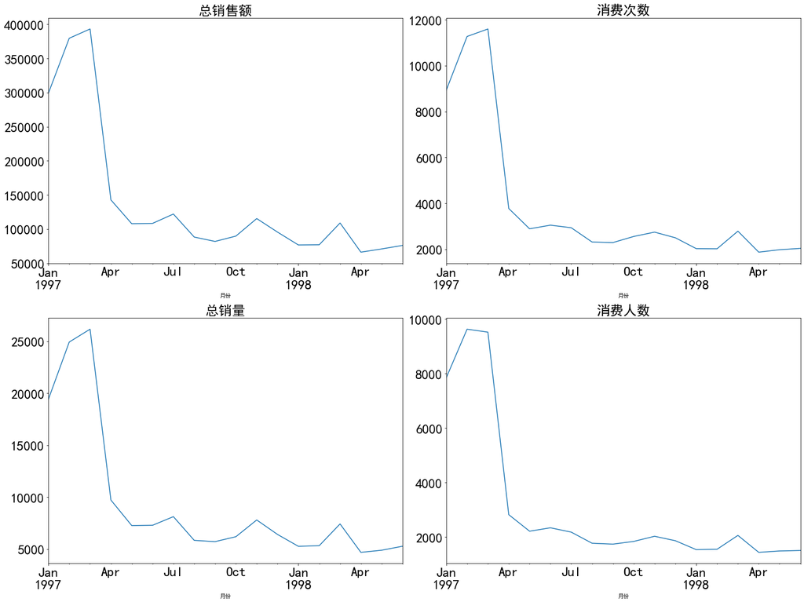

```python
plt.rcParams['font.sans-serif'] = ['SimHei']
plt.rcParams['axes.unicode_minus'] = False
# 设置图的大小，添加子图
plt.figure(figsize=(20,15))
# 每月的总销售额
plt.subplot(221)
df.groupby('月份')['订单金额'].sum().plot(fontsize=24)
plt.title('总销售额',fontsize=24)

#每月的消费次数
plt.subplot(222)
df.groupby('月份')['购买日期'].count().plot(fontsize=24)
plt.title('消费次数',fontsize=24)

#每月的销量
plt.subplot(223)
df.groupby('月份')['订单数'].sum().plot(fontsize=24)
plt.title('总销量',fontsize=24)

#每月的消费人数
plt.subplot(224)
df.groupby('月份')['用户ID'].apply(lambda x:len(x.unique())).plot(fontsize=24)
plt.title('消费人数',fontsize=24)
plt.tight_layout() # 设置子图的间距
plt.show()
```

### 四个折线图的整体趋势基本一致，可以看出来，1997年前3个月的销量特别高，随之而来的销售额也是暴涨，在3月份之后骤然下降，接近平稳。

### 对此提出问题和假设：

1、为什么会呈现这个原因呢？假设和客户有关，早期时间段的客户中有异常值，第二个假设是各类促销营销活动做的比较好，但这里只有消费数据，所以无法判断。

2、另一方面，在从2月到3月这段期间，为什么消费人数逐渐下降，反而但总销量与总销售额却依然上升呢？是不是在2-3月份中出现了大量重点发展的高价值客户？

## 用户个体消费分析

### 用户消费金额、消费次数分析

```python
# 根据用户id进行分组,统计出每个用户所有的订单数和消费金额总计
group_user = df.groupby('用户ID').sum()
group_user.describe()
```

|  | 订单数 | 订单金额 |
| --- | --- | --- |
| count | 23570.000000 | 23570.000000 |
| mean | 7.122656 | 106.080426 |
| std | 16.983531 | 240.925195 |
| min | 1.000000 | 0.000000 |
| 25% | 1.000000 | 19.970000 |
| 50% | 3.000000 | 43.395000 |
| 75% | 7.000000 | 106.475000 |
| max | 1033.000000 | 13990.930000 |

从客户角度看，每位客户平均购买7张CD，最多购买了1033张。客户的平均消费金额（客单价）106元，标准差是240，结合分位数和最大值看，平均值和75分位接近。因此，可以得出大部分客户都是低消费者，存在小部分高消费客户,这符合二八法则，说明当前产品的销售处于正常状态。

### 用户消费金额和消费次数分析

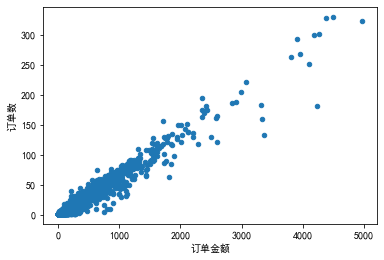

```python
#绘制用户消费金额和消费次数散点图
#为了去除异常数据的影响，设置查询条件为：订单金额 < 5000
group_user.query('订单金额 < 5000').plot.scatter(x='订单金额',y='订单数')
```

从上述散点图可以看出订单数和订单金额呈线性关系，这表示用户比较健康而且规律性很强，存在一些异常点，但数目不是很多，这可能以产品的种类单一有关。

### 用户消费金额分布图（二八法则）

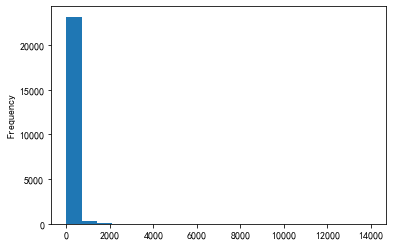

```python
group_user['订单金额'].plot.hist(bins = 20)
#bins = 20,分成20块，最高金额是14000，每个项是700
```

从上图可以看出，用户消费呈集中趋势，可能是受到了异常值的干扰导致。对此，可以先排除异常值再看看分布情况。

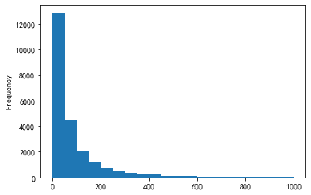

```python
group_user.query("订单金额< 1000")['订单金额'].plot.hist(bins=20)
```

2、从上图可以了解到大部分用户的消费能力不高，绝大部分呈现集中在较低的消费档次。高消费用户在图上几乎看不到，这也比较符合消费行为的二八法则。

3、虽然有异常数据的干扰，但是大部分的用户还是集中在比较低的消费档次。

### 用户消费次数分布图（二八法则）

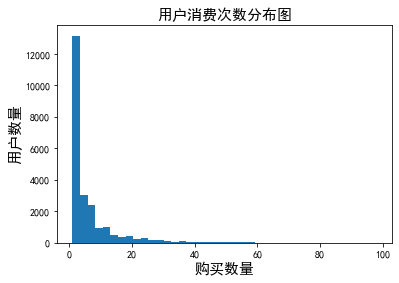

```python
group_user.query('订单数 < 100')['订单数'].plot.hist(bins = 40)
plt.xlabel('购买数量',fontsize=15)
plt.ylabel('用户数量',fontsize=15)
plt.title('用户消费次数分布图',fontsize=15)
```

可以看出大部分用户购买CD的数量都是在10张以内，购买大量CD的用户数量并不多，这可能与产品本身的情况有关。

### 用户消费周期分析

```python
#每个用户的每次购买时间间隔
order_diff = df.groupby('用户ID').apply(lambda x:x['购买日期'] - x['购买日期'].shift())
order_diff.head(10)
```

```
用户ID
1     0        NaT
2     1        NaT
      2     0 days
3     3        NaT
      4    87 days
      5     3 days
      6   227 days
      7    10 days
      8   184 days
4     9        NaT
Name: 购买日期, dtype: timedelta64[ns]
```

```python
order_diff.describe()
```

```
count                      46089
mean     68 days 23:22:13.567662
std      91 days 00:47:33.924168
min              0 days 00:00:00
25%             10 days 00:00:00
50%             31 days 00:00:00
75%             89 days 00:00:00
max            533 days 00:00:00
Name: 购买日期, dtype: object
```

可以看出平均每个用户的购买时间间隔大约是68天，间隔最长的是533天。因此，想要召回老客户，在60天左右的消费间隔是比较好的。而绝大部分用户的消费周期都低于100天。

### 用户消费周期分布图

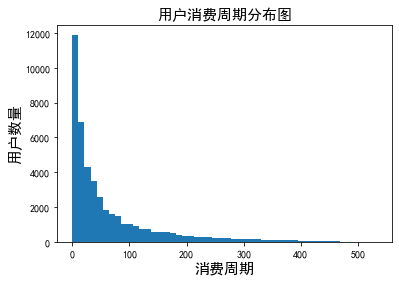

```python
plt.hist((order_diff / np.timedelta64(1, 'D')).dropna(), bins = 50)
plt.xlabel('消费周期',fontsize=15)
plt.ylabel('用户数量',fontsize=15)
plt.title('用户消费周期分布图',fontsize=15)
```

上图属于典型的（指数）长尾分布，其中大部分用户的消费间隔比较短。

解决方法：为了提高用户的消费周期，可以在用户消费后邀请用户加入粉丝群，并立即赠送优惠券，消费后5天左右询问用户商品体验情况，消费后15天左右提醒优惠券到期，消费后30天私信推送。

### 用户生命周期

```python
orderdt_min=df.groupby('用户ID').购买日期.min()#第一次消费
orderdt_max=df.groupby('用户ID').购买日期.max()#最后一次消费
differ = orderdt_max-orderdt_min
differ.head()
```

```
用户ID
1     0 days
2     0 days
3   511 days
4   345 days
5   367 days
Name: 购买日期, dtype: timedelta64[ns]
```

```python
# 用户平均生命周期
differ.mean()
```

```
Timedelta('134 days 20:55:36.987696')
```

所有用户的平均生命周期是134天，总体来看还是比较高的，但是平均数有时候也会出现误差，可以看一下分布情况。

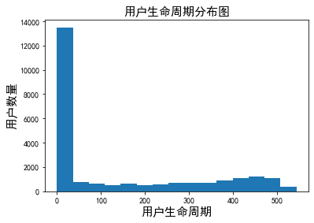

```python
(differ / np.timedelta64(1,'D')).plot.hist(bins=15)
plt.xlabel('用户生命周期',fontsize=15)
plt.ylabel('用户数量',fontsize=15)
plt.title('用户生命周期分布图',fontsize=15)
#因为数据类型是timedelta时间，无法直接作出直方图，所以先换算成数值。
#换算的方式直接除timedelta函数即可，np.timedelta64(1, ‘D’)，D表示天，1表示1天，作为单位使用的。
#因为max-min已经表示为天了，两者相除就是周期
```

得出以下结论：

1、大部分用户只消费了一次，大部分的生命周期都集中在了0天左右。

2、这和理想情况相差较大，可能是消费一次的用户数对于整个用户的分布影响较大，可以将只消费了一次的用户排除，只计算所有消费次数超过两次的老客的生命周期。

```python
#计算所有消费过两次以上的老客的生命周期
twice_life_time = (orderdt_max - orderdt_min).reset_index()
twice_life_time.head()
```

|  | 用户ID | 购买日期 |
| --- | --- | --- |
| 0 | 1 | 0 days |
| 1 | 2 | 0 days |
| 2 | 3 | 511 days |
| 3 | 4 | 345 days |
| 4 | 5 | 367 days |

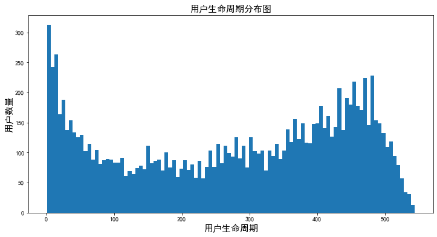

```python
#用户生命周期分布图
twice_life_time['life_time'] = twice_life_time['购买日期'] / np.timedelta64(1,'D')
plt.figure(figsize=(10,5))
twice_life_time[twice_life_time.life_time > 0]['life_time'].plot.hist(bins = 100, figsize = (12,6))
plt.xlabel('用户生命周期',fontsize=15)
plt.ylabel('用户数量',fontsize=15)
plt.title('用户生命周期分布图',fontsize=15)
```

从上图可以看出用户生命周期呈现双峰趋势，20天内生命周期的用户数量达到了高峰，400至500天内生命周期的用户数量是另一个高峰。

提升用户生命周期方案：

在用户购买后20天内对客户进行引导，促进其再次消费并形成消费习惯，延长其生命周期；生命周期在100至400天的用户，也要根据其需求特点推出有针对性的营销活动，促进其持续消费。

```python
#去掉0天生命周期的用户之后的用户生命周期的平均值
twice_life_time[twice_life_time.life_time>0]['购买日期'].mean()
```

```
Timedelta('276 days 01:04:31.344216')
```

```python
#用户生命周期留存率
life_time_rate =  twice_life_time[twice_life_time.life_time>0]['购买日期'].mean() / differ.mean()
print('life_time_rate=',life_time_rate)
```

```
life_time_rate= 2.0467176102813474
```

### 建立RFM模型框架

按用户价值分层---RFM模型 为了进行精细化运营，可以利用RMF模型对用户价值指数（衡量历史到当前用户贡献的收益）进行计算，其中 最近一次消费-R：客户最近一次交易时间的间隔。R值越大，表示客户交易发生的日期越久，反之则交易发生的日期越近。 消费频率-F：客户在最近一段时间内交易的次数。F值越大，表示客户交易越频繁，反之则表示客户交易不够活跃。 消费金额-M：客户在最近一段时间内交易的金额。M值越大，表示客户价值越高，反之则表示客户价值越低。 根据上述三个维度，对客户做细分

```python
rfm = df.pivot_table(index = '用户ID',
                     values = ['订单金额','购买日期','订单数'],
                     aggfunc = {'订单金额':'sum',
                                '购买日期':'max',
                                '订单数':'sum'})
rfm.head()
```

| 用户ID | 订单数 | 订单金额 | 购买日期 |
| --- | --- | --- | --- |
| 1 | 1 | 11.77 | 1997-01-01 |
| 2 | 6 | 89.00 | 1997-01-12 |
| 3 | 16 | 156.46 | 1998-05-28 |
| 4 | 7 | 100.50 | 1997-12-12 |
| 5 | 29 | 385.61 | 1998-01-03 |

```python
# 日期的最大值与当前日期的差值为R
rfm['R'] = (rfm['购买日期'].max() - rfm['购买日期']) / np.timedelta64(1,'D')
rfm.rename(columns = {'订单金额':'M',
                     '订单数':'F'},
          inplace=True)
rfm.head()
```

[output not shown]

```python
# 构建rfm模型公式
def get_rfm(x):
    level = x.apply(lambda x:'1' if x>=0 else '0')
    label = level['R'] + level['F'] + level['M']
    d = {'111':'重要价值客户',
        '011':'重要保持客户',
        '101':'重要挽留客户',
        '001':'重要发展客户',
        '110':'一般价值客户',
        '010':'一般保持客户',
        '100':'一般挽留客户',
        '000':'一般发展客户'}

    result = d[label]
    return result
rfm['label'] = rfm[['R','F','M']].apply(lambda x:(x-x.mean()) / x.std()).apply(get_rfm,axis=1)
rfm.head()
#求和
rfm.groupby('label').sum()
```

| label | F | M | R |
| --- | --- | --- | --- |
| 一般价值客户 | 650 | 7181.28 | 36295.0 |
| 一般保持客户 | 1712 | 19937.45 | 29448.0 |
| 一般发展客户 | 13977 | 196971.23 | 591108.0 |
| 一般挽留客户 | 29346 | 438291.81 | 6951815.0 |
| 重要价值客户 | 11121 | 167080.83 | 358363.0 |
| 重要保持客户 | 107789 | 1592039.62 | 517267.0 |
| 重要发展客户 | 2023 | 45785.01 | 56636.0 |
| 重要挽留客户 | 1263 | 33028.40 | 114482.0 |

```python
rfm.groupby('label').size()
```

```
label
一般价值客户       77
一般保持客户      206
一般发展客户     3300
一般挽留客户    14074
重要价值客户      787
重要保持客户     4554
重要发展客户      331
重要挽留客户      241
dtype: int64
```

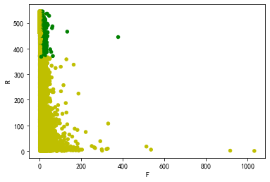

```python
rfm.loc[rfm.label == '重要价值客户', 'color'] = 'g'
rfm.loc[~(rfm.label == '重要价值客户'), 'color'] = 'y'
rfm.plot.scatter('F', 'R', c=rfm.color)
```

从上述可以看出在不同层次消费用户中，一般挽留用户的消费人数排名第一，有14074人，重要保持客户排名第二，有4554人，与一般挽留用户差距比较大，但累计消费金额最多。这中情况可能是因为极值的影响，业务方可以根据结果对客户分类运营，降低营销成本。

### 用户消费情况分析

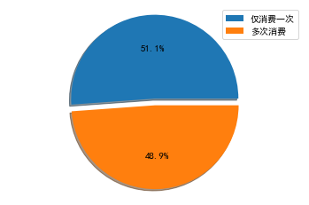

```python
#绘制用户消费饼图
a = df.groupby('用户ID')['购买日期'].agg(['min','max']).reset_index()
new_old = (a['min'] == a['max']).value_counts().values

plt.pie(x = new_old,
       autopct = '%.1f%%',
       shadow = True,
       explode = [0.08,0],
       textprops = {'fontsize' : 11})
plt.axis('equal')
plt.legend(['仅消费一次','多次消费'])
```

从上面饼图中可以看出有超过一半的用户仅消费了一次，这也说明了运营不利，用户留存效果不好。

#### 复购率：在某时间窗口内用户消费两次及以上的用户在总消费用户中占比。这里的时间窗口是月，如果一个用户在同一天下了两笔订单，这里也将他算作复购用户

```python
#每个用户在每月的订单数

pivoted_df=df.pivot_table(index='用户ID',columns='月份',values='购买日期',  #建立pivot_table透视表
                       aggfunc='count').fillna(0)#某些用户在某月没有消费过，用nan表示，这里用0填充
pivoted_df.head()
```

| 月份 用户ID | 1997-01-01 | 1997-02-01 | 1997-03-01 | 1997-04-01 | 1997-05-01 | 1997-06-01 | 1997-07-01 | 1997-08-01 | 1997-09-01 | 1997-10-01 | 1997-11-01 | 1997-12-01 | 1998-01-01 | 1998-02-01 | 1998-03-01 | 1998-04-01 | 1998-05-01 | 1998-06-01 |
| --- | --- | --- | --- | --- | --- | --- | --- | --- | --- | --- | --- | --- | --- | --- | --- | --- | --- | --- |
| 1 | 1.0 | 0.0 | 0.0 | 0.0 | 0.0 | 0.0 | 0.0 | 0.0 | 0.0 | 0.0 | 0.0 | 0.0 | 0.0 | 0.0 | 0.0 | 0.0 | 0.0 | 0.0 |
| 2 | 2.0 | 0.0 | 0.0 | 0.0 | 0.0 | 0.0 | 0.0 | 0.0 | 0.0 | 0.0 | 0.0 | 0.0 | 0.0 | 0.0 | 0.0 | 0.0 | 0.0 | 0.0 |
| 3 | 1.0 | 0.0 | 1.0 | 1.0 | 0.0 | 0.0 | 0.0 | 0.0 | 0.0 | 0.0 | 2.0 | 0.0 | 0.0 | 0.0 | 0.0 | 0.0 | 1.0 | 0.0 |
| 4 | 2.0 | 0.0 | 0.0 | 0.0 | 0.0 | 0.0 | 0.0 | 1.0 | 0.0 | 0.0 | 0.0 | 1.0 | 0.0 | 0.0 | 0.0 | 0.0 | 0.0 | 0.0 |
| 5 | 2.0 | 1.0 | 0.0 | 1.0 | 1.0 | 1.0 | 1.0 | 0.0 | 1.0 | 0.0 | 0.0 | 2.0 | 1.0 | 0.0 | 0.0 | 0.0 | 0.0 | 0.0 |

```python
#转换：消费2次以上记为1，消费1次记为0，消费0次记为NAN
#applymap针对dataframe所有数据

pivoted_df_transf=pivoted_df.applymap(lambda x: 1 if x>1 else np.nan if x==0 else 0)
pivoted_df_transf.head()
```

| 月份 用户ID | 1997-01-01 | 1997-02-01 | 1997-03-01 | 1997-04-01 | 1997-05-01 | 1997-06-01 | 1997-07-01 | 1997-08-01 | 1997-09-01 | 1997-10-01 | 1997-11-01 | 1997-12-01 | 1998-01-01 | 1998-02-01 | 1998-03-01 | 1998-04-01 | 1998-05-01 | 1998-06-01 |
| --- | --- | --- | --- | --- | --- | --- | --- | --- | --- | --- | --- | --- | --- | --- | --- | --- | --- | --- |
| 1 | 0.0 | NaN | NaN | NaN | NaN | NaN | NaN | NaN | NaN | NaN | NaN | NaN | NaN | NaN | NaN | NaN | NaN | NaN |
| 2 | 1.0 | NaN | NaN | NaN | NaN | NaN | NaN | NaN | NaN | NaN | NaN | NaN | NaN | NaN | NaN | NaN | NaN | NaN |
| 3 | 0.0 | NaN | 0.0 | 0.0 | NaN | NaN | NaN | NaN | NaN | NaN | 1.0 | NaN | NaN | NaN | NaN | NaN | 0.0 | NaN |
| 4 | 1.0 | NaN | NaN | NaN | NaN | NaN | NaN | 0.0 | NaN | NaN | NaN | 0.0 | NaN | NaN | NaN | NaN | NaN | NaN |
| 5 | 1.0 | 0.0 | NaN | 0.0 | 0.0 | 0.0 | 0.0 | NaN | 0.0 | NaN | NaN | 1.0 | 0.0 | NaN | NaN | NaN | NaN | NaN |

```python
#count统计所有非空数据个数表示总消费用户数，sum计算非0数据的和表示消费两次以上的用户数

df_duplicate =pd.DataFrame(pivoted_df_transf.sum()/pivoted_df_transf.count()).reset_index()
df_duplicate.columns = ['Date', 'DuplicatedRate']
df_duplicate['Date'] = df_duplicate.Date.astype(str).apply(lambda x:x[:-3])
df_duplicate.head()
```

|  | Date | DuplicatedRate |
| --- | --- | --- |
| 0 | 1997-01 | 0.107571 |
| 1 | 1997-02 | 0.122288 |
| 2 | 1997-03 | 0.155292 |
| 3 | 1997-04 | 0.223600 |
| 4 | 1997-05 | 0.196929 |

```
INFO:MainThread:matplotlib.category:Using categorical units to plot a list of strings that are all parsable as floats or dates. If these strings should be plotted as numbers, cast to the appropriate data type before plotting.
INFO:MainThread:matplotlib.category:Using categorical units to plot a list of strings that are all parsable as floats or dates. If these strings should be plotted as numbers, cast to the appropriate data type before plotting.
```

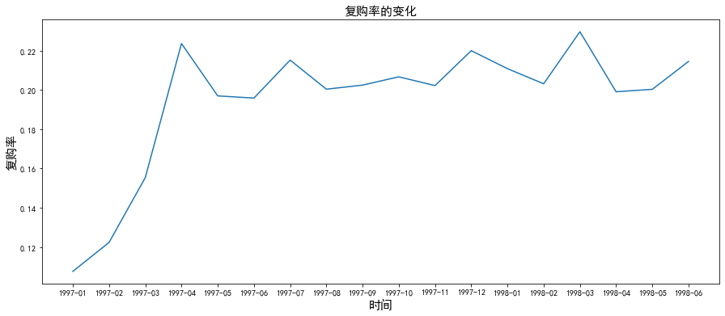

```python
#绘制复购率折线图

plt.figure(figsize = (15,6))
plt.plot(df_duplicate.Date, df_duplicate.DuplicatedRate)
plt.xlabel('时间', fontsize=15)
plt.ylabel('复购率',fontsize=15)
# plt.ylim(0,1)
plt.title('复购率的变化',fontsize=15)
```

#### 回购率：是某一个时间段内消费的用户，在下一个时间段仍旧消费的占比。

```python
#回购率
#每个用户每个月平均消费金额

pivoted_money=df.pivot_table(index='用户ID',columns='月份',values='订单金额',
                             aggfunc='mean').fillna(0)

columns_month=df.月份.sort_values().astype('str').unique()
pivoted_money.columns=columns_month
pivoted_money.head()
```

| 用户ID | 1997-01-01 | 1997-02-01 | 1997-03-01 | 1997-04-01 | 1997-05-01 | 1997-06-01 | 1997-07-01 | 1997-08-01 | 1997-09-01 | 1997-10-01 | 1997-11-01 | 1997-12-01 | 1998-01-01 | 1998-02-01 | 1998-03-01 | 1998-04-01 | 1998-05-01 | 1998-06-01 |
| --- | --- | --- | --- | --- | --- | --- | --- | --- | --- | --- | --- | --- | --- | --- | --- | --- | --- | --- |
| 1 | 11.77 | 0.0 | 0.00 | 0.00 | 0.00 | 0.00 | 0.00 | 0.00 | 0.00 | 0.0 | 0.000 | 0.000 | 0.00 | 0.0 | 0.0 | 0.0 | 0.00 | 0.0 |
| 2 | 44.50 | 0.0 | 0.00 | 0.00 | 0.00 | 0.00 | 0.00 | 0.00 | 0.00 | 0.0 | 0.000 | 0.000 | 0.00 | 0.0 | 0.0 | 0.0 | 0.00 | 0.0 |
| 3 | 20.76 | 0.0 | 20.76 | 19.54 | 0.00 | 0.00 | 0.00 | 0.00 | 0.00 | 0.0 | 39.205 | 0.000 | 0.00 | 0.0 | 0.0 | 0.0 | 16.99 | 0.0 |
| 4 | 29.53 | 0.0 | 0.00 | 0.00 | 0.00 | 0.00 | 0.00 | 14.96 | 0.00 | 0.0 | 0.000 | 26.480 | 0.00 | 0.0 | 0.0 | 0.0 | 0.00 | 0.0 |
| 5 | 21.65 | 38.9 | 0.00 | 45.55 | 38.71 | 26.14 | 28.14 | 0.00 | 40.47 | 0.0 | 0.000 | 43.465 | 37.47 | 0.0 | 0.0 | 0.0 | 0.00 | 0.0 |

```python
#将有消费的记为1，没有消费的记为0
pivoted_purchase=pivoted_money.applymap(lambda x:1 if x>0 else 0)
pivoted_purchase.head()
```

| 用户ID | 1997-01-01 | 1997-02-01 | 1997-03-01 | 1997-04-01 | 1997-05-01 | 1997-06-01 | 1997-07-01 | 1997-08-01 | 1997-09-01 | 1997-10-01 | 1997-11-01 | 1997-12-01 | 1998-01-01 | 1998-02-01 | 1998-03-01 | 1998-04-01 | 1998-05-01 | 1998-06-01 |
| --- | --- | --- | --- | --- | --- | --- | --- | --- | --- | --- | --- | --- | --- | --- | --- | --- | --- | --- |
| 1 | 1 | 0 | 0 | 0 | 0 | 0 | 0 | 0 | 0 | 0 | 0 | 0 | 0 | 0 | 0 | 0 | 0 | 0 |
| 2 | 1 | 0 | 0 | 0 | 0 | 0 | 0 | 0 | 0 | 0 | 0 | 0 | 0 | 0 | 0 | 0 | 0 | 0 |
| 3 | 1 | 0 | 1 | 1 | 0 | 0 | 0 | 0 | 0 | 0 | 1 | 0 | 0 | 0 | 0 | 0 | 1 | 0 |
| 4 | 1 | 0 | 0 | 0 | 0 | 0 | 0 | 1 | 0 | 0 | 0 | 1 | 0 | 0 | 0 | 0 | 0 | 0 |
| 5 | 1 | 1 | 0 | 1 | 1 | 1 | 1 | 0 | 1 | 0 | 0 | 1 | 1 | 0 | 0 | 0 | 0 | 0 |

```python
#如果本月进行消费，下月也进行消费，则记为1；如果下月没有消费，则记为0，若本月没有记为消费，则记为nan
def purchase_return(data):
    status=[]
    for i in range(17):          #循环17个月
        if data[i]==1:           #若本月消费
            if data[i+1]==1:     #下个月也消费
                status.append(1)  #就记为1
            if data[i+1]==0:     #下个月不消费，就记为0
                status.append(0)
        else:
            status.append(np.nan)
    status.append(np.nan)
    return pd.Series(status, index=columns_month)

pivoted_purchase_return=pivoted_purchase.apply(purchase_return,axis=1)#axis=1表示计算方向在行的方向上，左右运算
pivoted_purchase_return.head()
```

| 用户ID | 1997-01-01 | 1997-02-01 | 1997-03-01 | 1997-04-01 | 1997-05-01 | 1997-06-01 | 1997-07-01 | 1997-08-01 | 1997-09-01 | 1997-10-01 | 1997-11-01 | 1997-12-01 | 1998-01-01 | 1998-02-01 | 1998-03-01 | 1998-04-01 | 1998-05-01 | 1998-06-01 |
| --- | --- | --- | --- | --- | --- | --- | --- | --- | --- | --- | --- | --- | --- | --- | --- | --- | --- | --- |
| 1 | 0.0 | NaN | NaN | NaN | NaN | NaN | NaN | NaN | NaN | NaN | NaN | NaN | NaN | NaN | NaN | NaN | NaN | NaN |
| 2 | 0.0 | NaN | NaN | NaN | NaN | NaN | NaN | NaN | NaN | NaN | NaN | NaN | NaN | NaN | NaN | NaN | NaN | NaN |
| 3 | 0.0 | NaN | 1.0 | 0.0 | NaN | NaN | NaN | NaN | NaN | NaN | 0.0 | NaN | NaN | NaN | NaN | NaN | 0.0 | NaN |
| 4 | 0.0 | NaN | NaN | NaN | NaN | NaN | NaN | 0.0 | NaN | NaN | NaN | 0.0 | NaN | NaN | NaN | NaN | NaN | NaN |
| 5 | 1.0 | 0.0 | NaN | 1.0 | 1.0 | 1.0 | 0.0 | NaN | 0.0 | NaN | NaN | 1.0 | 0.0 | NaN | NaN | NaN | NaN | NaN |

```
INFO:MainThread:matplotlib.category:Using categorical units to plot a list of strings that are all parsable as floats or dates. If these strings should be plotted as numbers, cast to the appropriate data type before plotting.
INFO:MainThread:matplotlib.category:Using categorical units to plot a list of strings that are all parsable as floats or dates. If these strings should be plotted as numbers, cast to the appropriate data type before plotting.
```

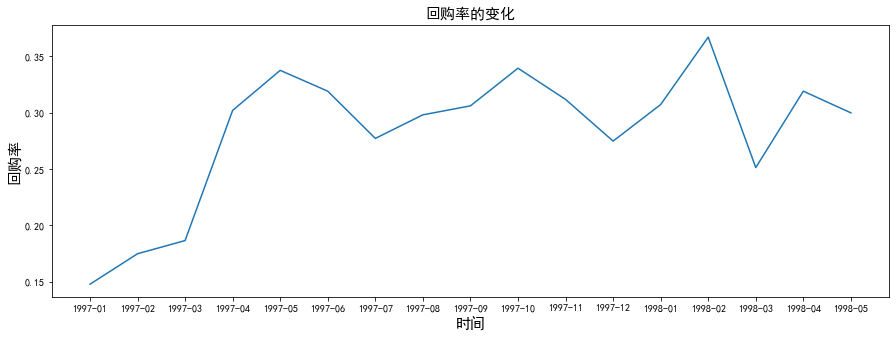

```python
df_purchase = (pivoted_purchase_return.sum() / pivoted_purchase_return.count()).reset_index()
df_purchase.columns = ['Date', 'PurchaseRate']
df_purchase['Date'] = df_purchase.Date.astype(str).apply(lambda x:x[:-3])

plt.figure(figsize = (15,5))
plt.plot(df_purchase.Date, df_purchase.PurchaseRate)
plt.xlabel('时间', fontsize=15)
plt.ylabel('回购率', fontsize=15)
plt.title('回购率的变化', fontsize=15)
```

**从上图得出以下结论：**

1、在初期用户的回购率并不高，1月的回购率只有15%左右，4月份起回购率稳定在30%左右。

3、对回购率的分析，再次说明了对于新用户，在其第一次消费后的三个月内是一段重要的时期，需要营销策略积极引导其再次消费及持续消费。

4、对于有持续消费的老客，也要适时推出反馈老客户的优惠活动，以加强老客的忠诚度。